# A Investigation on Titanic Dataset

## Statement of question

The goal of this investigation is to look through the Titanic dataset, to figure out **what kind of people are likely to survive from the Titanic disaster**

## Data wrangling

```python
import numpy as np
import pandas as pd
import matplotlib.pyplot as plt
import seaborn as sns
%pylab inline
```

First of all let's import and have a look at the dataset, to get a sense of what it is.

```python
df = pd.read_csv('titanic-data.csv')
```

```python
df.info()
```

```
<class 'pandas.core.frame.DataFrame'>
RangeIndex: 891 entries, 0 to 890
Data columns (total 12 columns):
PassengerId    891 non-null int64
Survived       891 non-null int64
Pclass         891 non-null int64
Name           891 non-null object
Sex            891 non-null object
Age            714 non-null float64
SibSp          891 non-null int64
Parch          891 non-null int64
Ticket         891 non-null object
Fare           891 non-null float64
Cabin          204 non-null object
Embarked       889 non-null object
dtypes: float64(2), int64(5), object(5)
memory usage: 83.6+ KB
```

It seems that this dataset have some missing data(age, cabin and embarked).

Also it has some feature we are not intereseted in: Since we are interested in what kind of people are likely to survive, we do not care information about their name, PassengerID, what Cabin they are i, Since such information is kind of in random, we could not tell people apart from these feature.

Feature we really interested in are feature that describe the difference of people, i.e. age, sex, social class they belongs to, number of child/ parent/ spouse/ brother&sister they take.

Also in dataset we have separate feature describe how many sib/spouse people take and how many parent/child they take. I think such feature is quite similar and could be merged into one feature.

```python
# As described above, we remove these useless feature.
df.drop(['Name'], inplace = True,axis = 1)
df.drop(['Cabin'], inplace = True,axis = 1)
df.drop(['Ticket'], inplace = True,axis = 1)
df.drop(['PassengerId'], inplace = True,axis = 1)

df.info()
```

```
<class 'pandas.core.frame.DataFrame'>
RangeIndex: 891 entries, 0 to 890
Data columns (total 8 columns):
Survived    891 non-null int64
Pclass      891 non-null int64
Sex         891 non-null object
Age         714 non-null float64
SibSp       891 non-null int64
Parch       891 non-null int64
Fare        891 non-null float64
Embarked    889 non-null object
dtypes: float64(2), int64(4), object(2)
memory usage: 55.8+ KB
```

```python
# merge similar features
df['family'] = df.SibSp + df.Parch
df.pop('SibSp')
df.pop('Parch')
df.info()
```

```
<class 'pandas.core.frame.DataFrame'>
RangeIndex: 891 entries, 0 to 890
Data columns (total 7 columns):
Survived    891 non-null int64
Pclass      891 non-null int64
Sex         891 non-null object
Age         714 non-null float64
Fare        891 non-null float64
Embarked    889 non-null object
family      891 non-null int64
dtypes: float64(2), int64(3), object(2)
memory usage: 48.8+ KB
```

Now let's deal with missing values.

Since the 'Embarked' feature have only 2 missing value, I'm going to find out these data, and fill the missing value based on similar people in the dataset if possible.

```python
#find out data that missing 'Embarked' value
df[df.Embarked.isnull()]
```

|  | Survived | Pclass | Sex | Age | Fare | Embarked | family |
| --- | --- | --- | --- | --- | --- | --- | --- |
| 61 | 1 | 1 | female | 38.0 | 80.0 | NaN | 0 |
| 829 | 1 | 1 | female | 62.0 | 80.0 | NaN | 0 |

```python
# see where similar people embark
temp = df[df.Pclass == 1]
temp = temp[temp.Sex == 'female']
temp = temp[temp.family == 0]
temp[temp.Survived == 1].Embarked.value_counts()
```

```
C    17
S    14
Name: Embarked, dtype: int64
```

```python
#see all the embark distribution
df.Embarked.value_counts()
```

```
S    644
C    168
Q     77
Name: Embarked, dtype: int64
```

We could not determine where these 2 sample embarked, since similar people are embarked from either S or C. Thus I'll leave thses feature data missing, and remove these 2 samples when related analysis involved.

```python
# now let's see what kind people have missing age
df[df.Age.isnull()]
```

|  | Survived | Pclass | Sex | Age | Fare | Embarked | family |
| --- | --- | --- | --- | --- | --- | --- | --- |
| 5 | 0 | 3 | male | NaN | 8.4583 | Q | 0 |
| 17 | 1 | 2 | male | NaN | 13.0000 | S | 0 |
| 19 | 1 | 3 | female | NaN | 7.2250 | C | 0 |
| 26 | 0 | 3 | male | NaN | 7.2250 | C | 0 |
| 28 | 1 | 3 | female | NaN | 7.8792 | Q | 0 |
| 29 | 0 | 3 | male | NaN | 7.8958 | S | 0 |
| 31 | 1 | 1 | female | NaN | 146.5208 | C | 1 |
| 32 | 1 | 3 | female | NaN | 7.7500 | Q | 0 |
| 36 | 1 | 3 | male | NaN | 7.2292 | C | 0 |
| 42 | 0 | 3 | male | NaN | 7.8958 | C | 0 |
| 45 | 0 | 3 | male | NaN | 8.0500 | S | 0 |
| 46 | 0 | 3 | male | NaN | 15.5000 | Q | 1 |
| 47 | 1 | 3 | female | NaN | 7.7500 | Q | 0 |
| 48 | 0 | 3 | male | NaN | 21.6792 | C | 2 |
| 55 | 1 | 1 | male | NaN | 35.5000 | S | 0 |
| 64 | 0 | 1 | male | NaN | 27.7208 | C | 0 |
| 65 | 1 | 3 | male | NaN | 15.2458 | C | 2 |
| 76 | 0 | 3 | male | NaN | 7.8958 | S | 0 |
| 77 | 0 | 3 | male | NaN | 8.0500 | S | 0 |
| 82 | 1 | 3 | female | NaN | 7.7875 | Q | 0 |
| 87 | 0 | 3 | male | NaN | 8.0500 | S | 0 |
| 95 | 0 | 3 | male | NaN | 8.0500 | S | 0 |
| 101 | 0 | 3 | male | NaN | 7.8958 | S | 0 |
| 107 | 1 | 3 | male | NaN | 7.7750 | S | 0 |
| 109 | 1 | 3 | female | NaN | 24.1500 | Q | 1 |
| 121 | 0 | 3 | male | NaN | 8.0500 | S | 0 |
| 126 | 0 | 3 | male | NaN | 7.7500 | Q | 0 |
| 128 | 1 | 3 | female | NaN | 22.3583 | C | 2 |
| 140 | 0 | 3 | female | NaN | 15.2458 | C | 2 |
| 154 | 0 | 3 | male | NaN | 7.3125 | S | 0 |
| ... | ... | ... | ... | ... | ... | ... | ... |
| 718 | 0 | 3 | male | NaN | 15.5000 | Q | 0 |
| 727 | 1 | 3 | female | NaN | 7.7375 | Q | 0 |
| 732 | 0 | 2 | male | NaN | 0.0000 | S | 0 |
| 738 | 0 | 3 | male | NaN | 7.8958 | S | 0 |
| 739 | 0 | 3 | male | NaN | 7.8958 | S | 0 |
| 740 | 1 | 1 | male | NaN | 30.0000 | S | 0 |
| 760 | 0 | 3 | male | NaN | 14.5000 | S | 0 |
| 766 | 0 | 1 | male | NaN | 39.6000 | C | 0 |
| 768 | 0 | 3 | male | NaN | 24.1500 | Q | 1 |
| 773 | 0 | 3 | male | NaN | 7.2250 | C | 0 |
| 776 | 0 | 3 | male | NaN | 7.7500 | Q | 0 |
| 778 | 0 | 3 | male | NaN | 7.7375 | Q | 0 |
| 783 | 0 | 3 | male | NaN | 23.4500 | S | 3 |
| 790 | 0 | 3 | male | NaN | 7.7500 | Q | 0 |
| 792 | 0 | 3 | female | NaN | 69.5500 | S | 10 |
| 793 | 0 | 1 | male | NaN | 30.6958 | C | 0 |
| 815 | 0 | 1 | male | NaN | 0.0000 | S | 0 |
| 825 | 0 | 3 | male | NaN | 6.9500 | Q | 0 |
| 826 | 0 | 3 | male | NaN | 56.4958 | S | 0 |
| 828 | 1 | 3 | male | NaN | 7.7500 | Q | 0 |
| 832 | 0 | 3 | male | NaN | 7.2292 | C | 0 |
| 837 | 0 | 3 | male | NaN | 8.0500 | S | 0 |
| 839 | 1 | 1 | male | NaN | 29.7000 | C | 0 |
| 846 | 0 | 3 | male | NaN | 69.5500 | S | 10 |
| 849 | 1 | 1 | female | NaN | 89.1042 | C | 1 |
| 859 | 0 | 3 | male | NaN | 7.2292 | C | 0 |
| 863 | 0 | 3 | female | NaN | 69.5500 | S | 10 |
| 868 | 0 | 3 | male | NaN | 9.5000 | S | 0 |
| 878 | 0 | 3 | male | NaN | 7.8958 | S | 0 |
| 888 | 0 | 3 | female | NaN | 23.4500 | S | 3 |

177 rows × 7 columns

Unlike 'Embarked' feature, we could not find any common in these samples, i.e. all the feature have different value, rather than same value, among these samples.

Thus, as before, I'll leave thses feature data missing, and remove these missing age samples when related analysis involved.

Also I noticed that feature 'Fare' and 'Age' have too much different values, which is not convienet in analysis. Thus, I'll map them into seperate blocks.

```python
df.Age.describe()
```

```
count    714.000000
mean      29.699118
std       14.526497
min        0.420000
25%       20.125000
50%       28.000000
75%       38.000000
max       80.000000
Name: Age, dtype: float64
```

```python
def map_age(age):
    'map numeric age into intervals'
    if (age >= 0) and (age <= 20):
        return '0-20'
    if (age > 20) and (age <= 40):
        return '20-40'
    if (age > 40) and (age <= 60):
        return '40-60'
    if (age > 38) and (age <= 100):
        return '60-80'
    else:
        return 'N/A'
df['Age'] = df.Age.apply(map_age)
```

```python
df.Fare.describe()
```

```
count    891.000000
mean      32.204208
std       49.693429
min        0.000000
25%        7.910400
50%       14.454200
75%       31.000000
max      512.329200
Name: Fare, dtype: float64
```

```python
def map_fare(fare):
    'map numeric fare into bins'
    if (fare >= 0) and (fare <= 8):
        return '0-8'
    if (fare > 8) and (fare <= 15):
        return '8-15'
    if (fare > 15) and (fare <= 31):
        return '15-31'
    if (fare > 31):
        return '31-512'
df['Fare'] = df.Fare.apply(map_fare)
```

## Exploration

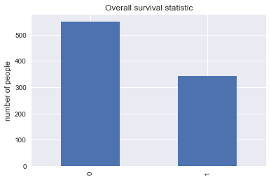

```
0 means dead, 1 means survived
```

```python
#First of all let's see and plot overall survival statistics
plt.title('Overall survival statistic')
df.Survived.value_counts().plot.bar()
plt.ylabel('number of people')
plt.show()
df.Survived.value_counts()
print '0 means dead, 1 means survived'
```

From the plot above we could see that most people died from that disaster, only 38% people survived.

Now let's see the relationship between survival rate and otehr features.

```python
def analysis(feature):
    'plot overall distribution in each feature first, then plot survival rate vs that feature'
    plt.title('Overall '+ feature + ' distribution in bar chart')
    plt.xlabel(feature)
    plt.ylabel('number of people')
    df[feature].value_counts().plot.bar()
    plt.show()
    plt.title('overall '+ feature + ' distribution in pie chart')
    df[feature].value_counts().plot.pie()
    plt.show()
    plt.title('survival rate vs '+ feature)
    group = df.groupby(feature)
    plt.xlabel("Survival rate")
    group.Survived.mean().plot.barh()
```

### How Embarked place affect survival rate

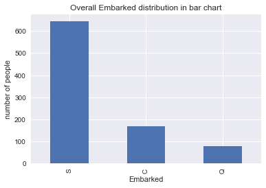

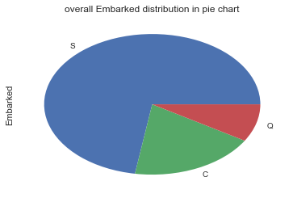

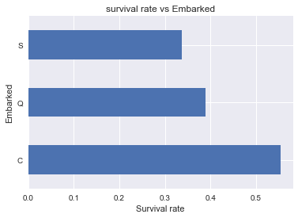

```python
analysis('Embarked')
```

### How Sex affect survival rate

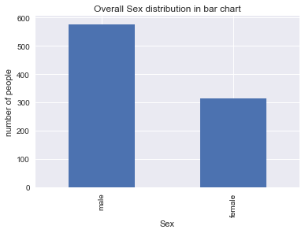

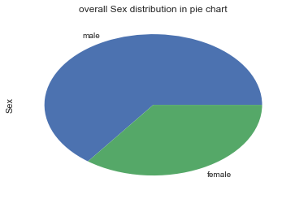

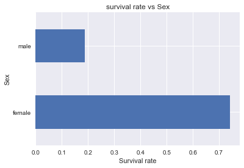

```python
analysis('Sex')
```

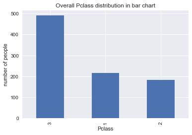

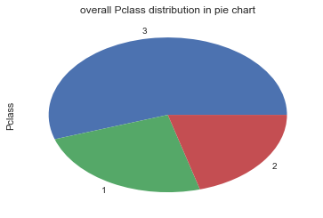

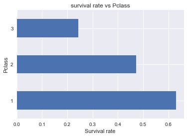

```python
analysis('Pclass')
```

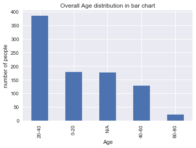

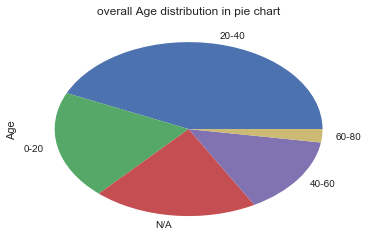

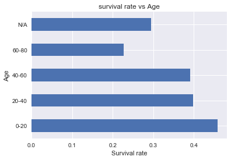

```python
analysis('Age')
```

### How Fare affect survival rate

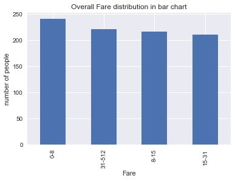

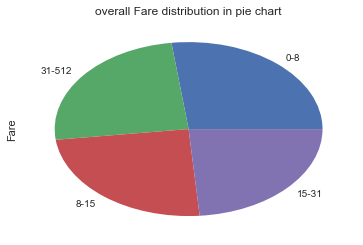

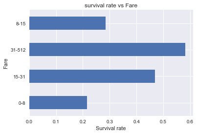

```python
analysis('Fare')
```

### How family member number affect survival rate

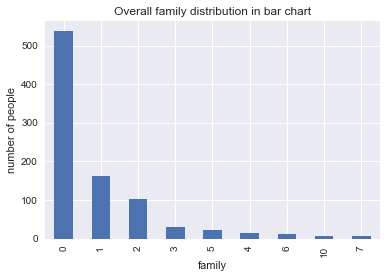

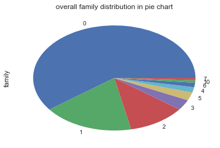

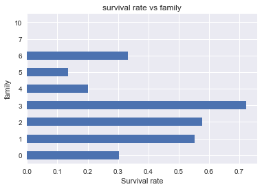

```python
analysis('family')
```

#### Summary

From the plot above we can get a sense of what kind of people are likely to survive:

Female is more likely to survive since they have over 70% survival rate while male below 20%.

Upper class people are more likely to survive, since they have over 60% survival rate while middle class have around 47% and bottom class have only 25%.

People over 60 have less possible to survive, while children have a little bit more change than others.

Similar to Pclass, the more Fare people pay, the more chance people could survive.

Interestly the place of embark also affect the survival rate, survivla rate from C is significantly higher than S and Q.

Family member number seems not so relevant to the survival rate, since most of people take no family member on the ship, others have too little sample that could easily affected by other factors.

### Feature Combination analysis

Generally speaking, people from upper class are more likely to pay more fare,let's see how these 2 factor affect survival rate.

```python
def combination(features):
    df.groupby(features).Survived.mean().plot.barh()
    plt.xlabel('survival rate')
    title = 'survival rate with'
    for item in features:
        title = title + ' '+ item
    plt.title( title)
```

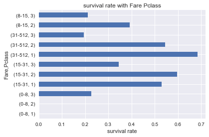

```python
combination(['Fare','Pclass'])
```

Interestingly we observed that although some bottom class people paied the expensive(31-512) fare, their survival rate still significantly lower than middle or upper class people who pay moderate(8-31) fare.

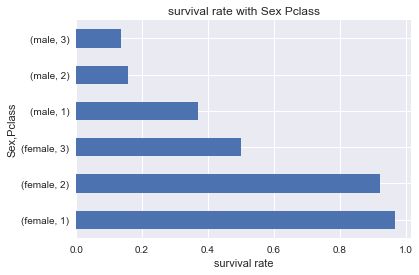

```python
combination(['Sex','Pclass'])
```

Plot above explores the influence of both gender and Pclass on the survival rate. From the plot we could easily see that although upper class have higher survival rate, upper class male still have lower survival rate than bottom class female. This means gender have more influence than Plclass on this dataset.

## Conclusion

This simple investigation on Titanic dataset reveled the fact that young female, upper class who paied expensive fare have the most chance to survive on the disaster.

Gender have the most influence on the survival rate, then is the social class(Pclass), and how much Fare you paied. Age and number of family member seems not so relevant to the survival rate compare to previous factor.

There are also limitation on this investigation:

First of all, this dataset itself is only part of the data about people on the Tatanic. Also missing values in the dataset make it less reliable.

Second, this investigation only make simple analysis on the dataset, i.e. exlore how 1 or 2 factor affect the sirvival rate with plots.